# KWF_metals_2020

Document last updated 2021-04-26 08:22:41 by Benjamin Meyer (ben@kenaiwatershed.org)

This draft document contains preliminary data explorations of 2019-2020 copper and zinc water quality data from the Kenai River Watershed.

Notes:

- Attempted to source 2019-2020 data from AWQMS formatted files found on KWF server, but was unable to locate all known 2019 - 2020 data there. See the document https://rpubs.com/Kenai_Watershed_Forum/cu_zn_2019_2020_initial_EDA for further discussion and recommended actions.
- Next, I queried the US EPA water quality data portal. I found Cu, Zn, Mg, and Ca data pre-2013 there at https://www.waterqualitydata.us/portal/, but did not yet find 2014-2020 data there. I later discovered that 2014 - 2020 has not yet been submitted to the EPA database (see https://rpubs.com/kwf/krbwqm). It is a high priority to elevate this data as soon as feasible in 2021.
- Specific query used: https://www.waterqualitydata.us/portal/#countrycode=US&statecode=US%3A02&countycode=US%3A02%3A122&sampleMedia=water&sampleMedia=Water&characteristicType=Inorganics%2C%20Major%2C%20Metals&characteristicType=Inorganics%2C%20Minor%2C%20Metals&mimeType=csv&dataProfile=narrowResult
- In the future it will be important to be able to read in final data directly from the EPA institutional archive, in its most static version.
- In cases 2019 where hardness data not available, data from nearest sampling event was used instead. See written report for further description.
- On Feb 16, 2021, KWF received a verbal update to the QAPP regarding replicate values from Gretchen Augat and Laura Eldred (ADEC). QAPPs (and work plans) approved in 2020 specified that in cases where two replicate values exist, the higher of the two values should be used. New guidance as of Feb. 2021 is that in cases where two replicate samples exist; one sample is designated “the sample” and the other is designated “the replicate.” Relative difference level (RDL) values should still be reported where appropriate, but for data summaries analyses, only “the sample” values should be used.
- Analyses here do not reflect this new ADEC guidance, because they were not part of the original workplan.

### Data Read in and preparation

Read in results columns directly from tabs “FINALREPORT_ZnCuSampling_19-20” and “FINALREPORT_Baseline_19-20” in the Excel document “AllData_ZnCuCaMg_19-20.xlsx” prepared by MH in Fall 2020

```r
# specify file paths and sheet names
workbook <- "data/AllData_ZnCuCaMg_19-20.xlsx"
tab <- "BM_format_2020"

# read in tabs
tbl <- read_excel(workbook, sheet = tab, skip = 1)

# assign new column names
vars <- c("site","rm","date","waterbody_type","hardness_mgL","copper_ugL","copper_ccc_ugL","zinc_ugL","zinc_ccc_ugL")
colnames(tbl) <- vars

# create numerical columns and clean data table
tbl <- tbl%>%
  select(-rm) %>%
  filter(!is.na(date)) %>%
  fill(site) %>%
  transform(date = as.Date(date, origin = "1899-12-30")) %>%

  # hardness
  separate(hardness_mgL, sep = " ", into = c("hardness_mgL_1","hardness_mgL_2"), remove = F) %>%
  mutate(hardness_mgL_2 = gsub("[()]", "", hardness_mgL_2)) %>%

  # copper
  mutate(copper_ugL_x = gsub("[()]", "", copper_ugL)) %>%
  mutate(copper_ugL_x = gsub("J", "", copper_ugL_x)) %>%
  mutate(copper_ugL_x = gsub("U", "", copper_ugL_x)) %>%
  mutate(copper_ugL_x = str_replace(copper_ugL_x, "\\s", "|")) %>%
  ### replace first white space with consistent character and split on that character
  separate(copper_ugL_x, into = c("copper_ugL_1", "copper_ugL_2"), sep = "\\|") %>%

  # copper CCC
  mutate(copper_ccc_ugL_x = gsub("[()]", "", copper_ccc_ugL)) %>%
  mutate(copper_ccc_ugL_x = gsub("J", "", copper_ccc_ugL_x)) %>%
  mutate(copper_ccc_ugL_x = gsub("U", "", copper_ccc_ugL_x)) %>%
  mutate(copper_ccc_ugL_x = str_replace(copper_ccc_ugL_x, "\\s", "|")) %>%

  ### replace first white space with consistent character and split on that character
  separate(copper_ccc_ugL_x, into = c("copper_ccc_ugL_1", "copper_ccc_ugL_2"), sep = "\\|") %>%

  # zinc
  mutate(zinc_ugL_x = gsub("[()]", "", zinc_ugL)) %>%
  mutate(zinc_ugL_x = gsub("J", "", zinc_ugL_x)) %>%
  mutate(zinc_ugL_x = gsub("U", "", zinc_ugL_x)) %>%
  mutate(zinc_ugL_x = str_replace(zinc_ugL_x, "\\s", "|")) %>%
  ### replace first white space with consistent character and split on that character
  separate(zinc_ugL_x, into = c("zinc_ugL_1", "zinc_ugL_2"), sep = "\\|") %>%

  # zinc CCC
  mutate(zinc_ccc_ugL_x = gsub("[()]", "", zinc_ccc_ugL)) %>%
  mutate(zinc_ccc_ugL_x = gsub("J", "", zinc_ccc_ugL_x)) %>%
  mutate(zinc_ccc_ugL_x = gsub("U", "", zinc_ccc_ugL_x)) %>%
  mutate(zinc_ccc_ugL_x = str_replace(zinc_ccc_ugL_x, "\\s", "|")) %>%

  ### replace first white space with consistent character and split on that character
  separate(zinc_ccc_ugL_x, into = c("zinc_ccc_ugL_1", "zinc_ccc_ugL_2"), sep = "\\|") %>%

  # select desired columns
  select("site","date","waterbody_type",
         "hardness_mgL_1","hardness_mgL_2",
         "copper_ugL_1","copper_ugL_2","copper_ccc_ugL_1","copper_ccc_ugL_2",
         "zinc_ugL_1","zinc_ugL_2","zinc_ccc_ugL_1","zinc_ccc_ugL_2") %>%

  # transform numbers to numeric column classes
  mutate_at(c("hardness_mgL_1","hardness_mgL_2",
         "copper_ugL_1","copper_ugL_2","copper_ccc_ugL_1","copper_ccc_ugL_2",
         "zinc_ugL_1","zinc_ugL_2","zinc_ccc_ugL_1","zinc_ccc_ugL_2"),
         as.numeric) %>%

  # modify site names
  mutate(site = as.factor(str_replace_all(site," ","_"))) %>%
  mutate(site = as.factor(str_replace_all(site,"-","_"))) %>%
  mutate(site = as.factor(str_replace_all(site,"'","")))
```

Export hardness values for use in the script “calcium_magnesium_historical_data.Rmd”

```r
hardness_tbl <- tbl %>%
  select(site,date,waterbody_type,hardness_mgL_1,hardness_mgL_2) %>%
  pivot_longer(cols = c("hardness_mgL_1","hardness_mgL_2"), names_to = "obs", values_to = "val") %>%
  filter(!is.na(val))

write.csv(hardness_tbl,"output/hardness_2019_2020.csv", row.names = F)
```

### Duplicate sample % differences

- Calculate RDL values for Zn and Cu duplicate samples
- In cases where a “_2” value exists, this is the “replicate” value

```r
tbl <- tbl %>%
  ## copper rdl
  mutate(cu_rdl = paste(sprintf((abs(copper_ugL_1 - copper_ugL_2) / ((copper_ugL_1 + copper_ugL_2) / 2)*100), fmt = '%#.2f'),"%")) %>%
  mutate(cu_rdl = str_replace(cu_rdl, "NA %", "")) %>%

  # zinc rdl
  mutate(zn_rdl = paste(sprintf((abs(zinc_ugL_1 - zinc_ugL_2) / ((zinc_ugL_1 + zinc_ugL_2) / 2)*100), fmt = '%#.2f'),"%")) %>%
  mutate(zn_rdl = str_replace(zn_rdl, "NA %", ""))

  # ca rdl

  # mg rdl

# write rdl table
rdl_tbl <- tbl %>%
  ungroup() %>%
  filter(!is.na(cu_rdl),
         cu_rdl != "") %>%
  arrange(site,date) %>%
  select(site,date,cu_rdl,zn_rdl) %>%
  pivot_longer(cols = c("cu_rdl","zn_rdl"), values_to = "RDL") %>%
  mutate(name = str_replace_all(name,"cu_rdl","Copper"),
         name = str_replace_all(name,"zn_rdl","Zinc")) %>%
  arrange(name,site,date)

# rename columns
colnames(rdl_tbl) <- c("Site","Date","Parameter","RDL(%)")

# export RDL table
#write.csv(rdl_tbl, "output/rdl_tbl.csv", row.names = F)

datatable(rdl_tbl,
          filter = 'top',
          options = list(pageLength = 5, autoWidth = TRUE))
```

|  | Site | Date | Parameter | RDL(%) |
| --- | --- | --- | --- | --- |
| 1 | City_of_Kenai_Docks | 2019-04-30 | Copper | 38.85 % |
| 2 | Jims_Landing | 2020-05-20 | Copper | 5.44 % |
| 3 | Lower_No_Name_Creek | 2019-07-30 | Copper | 148.32 % |
| 4 | Lower_No_Name_Creek | 2020-07-21 | Copper | 112.66 % |
| 5 | Lower_Slikok_Creek | 2019-04-30 | Copper | 44.12 % |
| 6 | Skilak_Lake_Outlet | 2020-05-20 | Copper | 4.19 % |
| 7 | Slikok_Creek_Kenai_River_Confluence | 2020-05-20 | Copper | 3.95 % |
| 8 | Slikok_Creek_Kenai_River_Confluence | 2020-07-22 | Copper | 2.96 % |
| 9 | Upper_Beaver_Creek | 2020-05-20 | Copper | 0.00 % |
| 10 | Upper_Beaver_Creek | 2020-07-22 | Copper | 0.00 % |

[output cut: 20 more lines]

What was the average percent difference for duplicate samples?

```r
z <- rdl_tbl %>%
  mutate(`RDL(%)` = str_remove(`RDL(%)`,"%")) %>%
  transform(`RDL(%)` = as.numeric(`RDL(%)`)) %>%
  rename(RDL_pct = `RDL...`) %>%
  group_by(Parameter) %>%
  summarise(mean = mean(RDL_pct),
            se = std.error(RDL_pct))

colnames(z) <- c("Metal", "Mean RDL (%)","Std. Error(%)")

z
```

| Metal | Mean RDL (%) | Std. Error(%) |
| --- | --- | --- |
| Copper | 38.88533 | 13.60674 |
| Zinc | 34.76933 | 14.31372 |

### Raw Data Table

```r
# read in coordinates
coords <- read_excel("data/Sampling sites 2020.xlsx", sheet = "BM_format_Sites2020") %>%
  rename(site = Site) %>%
  transform(site = as.factor(site))

# join coordinates to data
tbl <- left_join(tbl,coords)

# present table
datatable(tbl,
          filter = 'top',
          options = list(pageLength = 5, autoWidth = TRUE))
```

|  | site | date | waterbody_type | hardness_mgL_1 | hardness_mgL_2 | copper_ugL_1 | copper_ugL_2 | copper_ccc_ugL_1 | copper_ccc_ugL_2 | zinc_ugL_1 | zinc_ugL_2 | zinc_ccc_ugL_1 | zinc_ccc_ugL_2 | cu_rdl | zn_rdl | Habitat | Site_1 | Lat | Long | BM_Notes | Other_Notes |
| --- | --- | --- | --- | --- | --- | --- | --- | --- | --- | --- | --- | --- | --- | --- | --- | --- | --- | --- | --- | --- | --- |
| 1 | Lower_No_Name_Creek | 2019-04-30 | Tributary | 32.59 |  | 0.668 |  | 4.4 |  | 21.3 |  | 39.92 |  |  |  | Tributary | Lower No Name Creek | 60.550888 | -151.268417 | Coordinates from Guerron Orejuela 2015 KWF report |  |
| 2 | Lower_No_Name_Creek | 2019-07-30 | Tributary | 51.22 | 50.85 | 0.451 | 3.04 | 6.48 | 6.44 | 5.53 | 5.31 | 58.56 | 58.2 | 148.32 % | 4.06 % | Tributary | Lower No Name Creek | 60.550888 | -151.268417 | Coordinates from Guerron Orejuela 2015 KWF report |  |
| 3 | Lower_No_Name_Creek | 2020-07-21 | Tributary | 49.86 | 1579.89 | 0.5 | 1.79 | 6.33 | 121.31 | 5 | 3.75 | 57.24 | 1069.95 | 112.66 % | 28.57 % | Tributary | Lower No Name Creek | 60.550888 | -151.268417 | Coordinates from Guerron Orejuela 2015 KWF report |  |
| 4 | Upper_No_Name_Creek | 2019-05-22 | Tributary | 32.58547 |  | 0.53 | 3.27 | 4.40078491869142 |  | 98.1 | 159 | 39.9166826118958 |  | 144.21 % | 47.37 % | Tributary | Upper No Name Creek | 60.577846 | -151.268588 | Coordinates provided by MH |  |
| 5 | Upper_No_Name_Creek | 2019-07-24 | Tributary | 50.84966 |  | 0.39 | 0.61 | 6.43686330268534 |  | 5.12 | 5.77 | 58.1978689484972 |  | 44.00 % | 11.94 % | Tributary | Upper No Name Creek | 60.577846 | -151.268588 | Coordinates provided by MH |  |
| 6 | Upper_No_Name_Creek | 2020-05-20 | Tributary | 15.58 | 15.33 | 0.606 | 0.497 | 2.34 | 2.31 | 10.9 | 7.05 | 21.36 | 21.07 | 19.76 % | 42.90 % | Tributary | Upper No Name Creek | 60.577846 | -151.268588 | Coordinates provided by MH |  |
| 7 | Upper_No_Name_Creek | 2020-07-22 | Tributary | 82.32 |  | 1.04 |  | 9.71 |  | 3.46 |  | 87.53 |  |  |  | Tributary | Upper No Name Creek | 60.577846 | -151.268588 | Coordinates provided by MH |  |
| 8 | Lower_Beaver_Creek | 2019-04-30 | Tributary | 43.06 |  | 3.91 |  | 5.58 |  | 84.1 |  | 50.55 |  |  |  | Tributary | Lower Beaver Creek | 60.548029 | -151.14324 | Coords estimated by B Meyer from Fig. 1 in 2019 report and Google Earth |  |
| 9 | Lower_Beaver_Creek | 2019-07-30 | Tributary | 73.65 |  | 1.77 |  | 8.83 |  | 69.9 |  | 79.66 |  |  |  | Tributary | Lower Beaver Creek | 60.548029 | -151.14324 | Coords estimated by B Meyer from Fig. 1 in 2019 report and Google Earth |  |
| 10 | Lower_Beaver_Creek | 2020-07-21 | Tributary | 63.36 |  | 0.509 |  | 7.77 |  | 3.27 |  | 70.12 |  |  |  | Tributary | Lower Beaver Creek | 60.548029 | -151.14324 | Coords estimated by B Meyer from Fig. 1 in 2019 report and Google Earth |  |

[output cut: 54 more lines]

### Map

```r
# add site identifier
tbl <- tbl %>%
  group_by(site) %>%
  mutate(Site_ID = cur_group_id())


# used arcgis online from csv exported here
write.csv(tbl, "output/CuZn_2019_2020_results.csv", row.names = F)

# viewable at https://arcg.is/0yij15
```

#### Site coordinates

```r
cd <- coords %>%
  select(site,Habitat,Lat,Long)

datatable(cd,
          filter = 'top',
          options = list(pageLength = 5, autoWidth = TRUE))
```

|  | site | Habitat | Lat | Long |
| --- | --- | --- | --- | --- |
| 1 | Lower_No_Name_Creek | Tributary | 60.550888 | -151.268417 |
| 2 | Upper_No_Name_Creek | Tributary | 60.577846 | -151.268588 |
| 3 | Lower_Soldotna_Creek | Tributary | 60.483364 | -151.057656 |
| 4 | Upper_Soldotna_Creek | Tributary | 60.550828 | -150.958325 |
| 5 | Lower_Beaver_Creek | Tributary | 60.548029 | -151.14324 |
| 6 | Upper_Beaver_Creek | Tributary | 60.641201 | -151.084718 |
| 7 | Lower_Slikok_Creek | Tributary | 60.482318 | -151.127053 |
| 8 | Upper_Slikok_Creek | Tributary | 60.402664 | -151.147385 |
| 9 | Lower_Funny_River | Tributary | 60.489963 | -150.860982 |
| 10 | City_of_Kenai_Docks | Mainstem | 60.54368 | -151.22294 |

[output cut: 9 more lines]

#### ArcGIS Online map

Sampling sites and raw data on an interactive map (also at https://arcg.is/0yij15)

[interactive chart not shown]

### Plots

Prep tables for plotting

```r
# prep table

# strategy to prep for ggplot (e.g. "long form": break up in to minimum tables and use joins to rebuild min rows?
tbl <- tbl %>%
  select(site, date, waterbody_type,
         starts_with(c("copper","cu","zinc","zn")),
         Lat, Long, BM_Notes)

# rdl table
rdl_tbl <- tbl %>%
  select(site,date,contains("rdl")) %>%
  filter(zn_rdl != "") %>%
  pivot_longer(contains("rdl"),names_to = "rdl", values_to = "rdl_val") %>%
  mutate(metal = gsub("_rdl","",rdl)) %>%
  select(-rdl)

# ccc table
ccc_tbl <- tbl %>%
  select(site,date,contains("ccc")) %>%
  pivot_longer(contains("ccc"), values_to = "ccc_val") %>%
  filter(!is.na(ccc_val)) %>%
  mutate(metal = gsub("copper","cu",name)) %>%
  mutate(metal = gsub("zinc","zn",metal)) %>%
  mutate(metal = gsub("_ccc_ugL_1","",metal)) %>%
  mutate(metal = gsub("_ccc_ugL_2","",metal)) %>%
  select(-name)

# metal values observations
met_obs <- c("copper_ugL_1","copper_ugL_2","zinc_ugL_1","zinc_ugL_2")
met_tbl <- tbl %>%
  select(site,date,all_of(met_obs)) %>%
  pivot_longer(met_obs, names_to = "metal", values_to = "met_val") %>%
  filter(!is.na(met_val)) %>%
  mutate(metal = gsub("copper","cu",metal)) %>%
  mutate(metal = gsub("zinc","zn",metal)) %>%
  mutate(metal = gsub("_ugL_1","",metal)) %>%
  mutate(metal = gsub("_ugL_2","",metal)) %>%
  distinct()


# join tables in long form
tbl2 <- inner_join(met_tbl,ccc_tbl) %>%
  left_join(rdl_tbl) %>%
  left_join(coords) %>%
  arrange(metal,met_val) %>%
  distinct()
```

Summarise the range of metal and CCC values observed

```r
dt <- tbl2 %>%
  group_by(site,metal) %>%
  summarise(met_max = max(met_val),
            met_min = min(met_val),
            ccc_max = max(ccc_val),
            ccc_min = min(ccc_val)) %>%
  arrange(metal, met_max)

datatable(dt,
          filter = 'top',
          options = list(pageLength = 5, autoWidth = TRUE))
```

|  | site | metal | met_max | met_min | ccc_max | ccc_min |
| --- | --- | --- | --- | --- | --- | --- |
| 1 | Swiftwater_Park | cu | 0.462 | 0.359 | 4.58 | 4.11 |
| 2 | Poachers_Cove | cu | 0.5 | 0.42 | 4.62 | 4.1 |
| 3 | Lower_Funny_River | cu | 0.514 | 0.363 | 5.47 | 4.61 |
| 4 | Upper_Slikok_Creek | cu | 0.53 | 0.431 | 8.82699361785495 | 2.83 |
| 5 | Lower_Soldotna_Creek | cu | 0.597 | 0.424 | 9.62 | 7.3 |
| 6 | Jims_Landing | cu | 0.643 | 0.447 | 5.57108735256244 | 4.79 |
| 7 | Upstream_of_Beaver_Creek | cu | 0.66 | 0.497 | 4.59 | 4.24 |
| 8 | Pillars | cu | 0.681 | 0.452 | 4.55 | 4.2 |
| 9 | Skilak_Lake_Outlet | cu | 0.696 | 0.313 | 4.52 | 3.91 |
| 10 | Soldotna_Bridge | cu | 0.716 | 0.348 | 4.52 | 4.14 |

[output cut: 28 more lines]

#### Tributary site plots

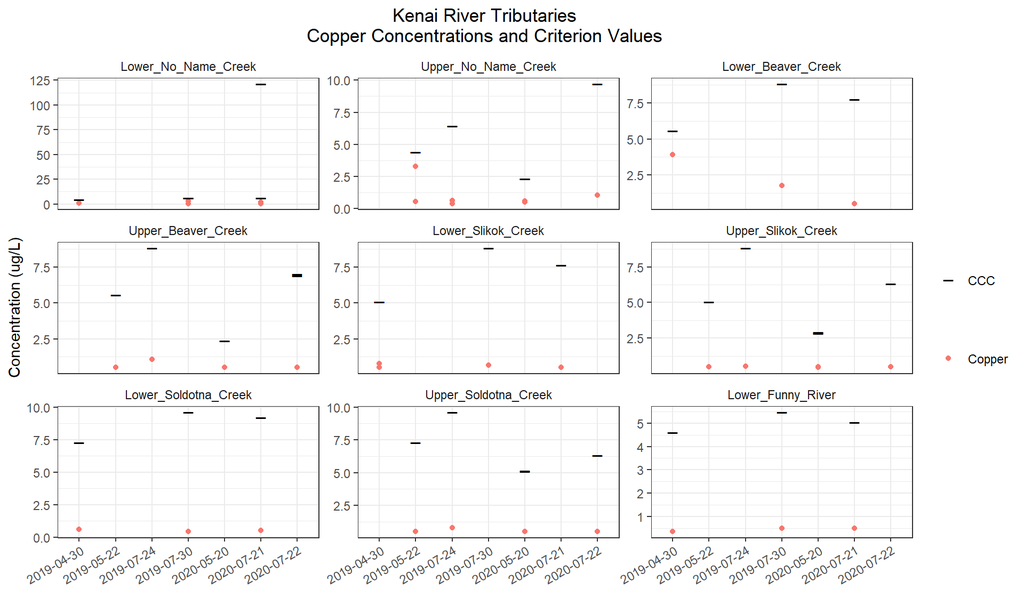

```r
## tributaries
trib_order <- c("Lower_No_Name_Creek",
                "Upper_No_Name_Creek",
                "Lower_Beaver_Creek",
                "Upper_Beaver_Creek",
                "Lower_Slikok_Creek",
                "Upper_Slikok_Creek",
                "Lower_Soldotna_Creek",
                "Upper_Soldotna_Creek",
                "Lower_Funny_River")
tbl2_trib <- tbl2 %>% filter(Habitat == "Tributary")
tbl2_trib$site <- factor(tbl2_trib$site, levels = trib_order)

# common theme
cuzn_theme <- theme(
  strip.text.y = element_text(face = "bold", angle = 0),
        axis.text.x = element_text(angle = 30, hjust = 1, vjust = 1),

        plot.title = element_text(hjust = 0.5),
        strip.background = element_blank())

# copper in tributaries
(cu_tribs <- tbl2_trib %>%
    filter(metal == "cu") %>%
  ggplot() +
  geom_point(aes(as.factor(date),as.numeric(met_val), color = "Copper")) +
  geom_point(aes(as.factor(date),as.numeric(ccc_val), fill = "CCC"), shape = 95, size = 4) +
    scale_color_discrete(name = "") +
    scale_fill_discrete(name = "") +
  facet_wrap(site ~ ., scales = "free_y") +
  theme_bw() +
  cuzn_theme +
  xlab("") +
  ylab("Concentration (ug/L)") +
  ggtitle("Kenai River Tributaries\nCopper Concentrations and Criterion Values"))
```

```r
# save to output folder
ggsave("output/figures/cu_tribs.png")
```

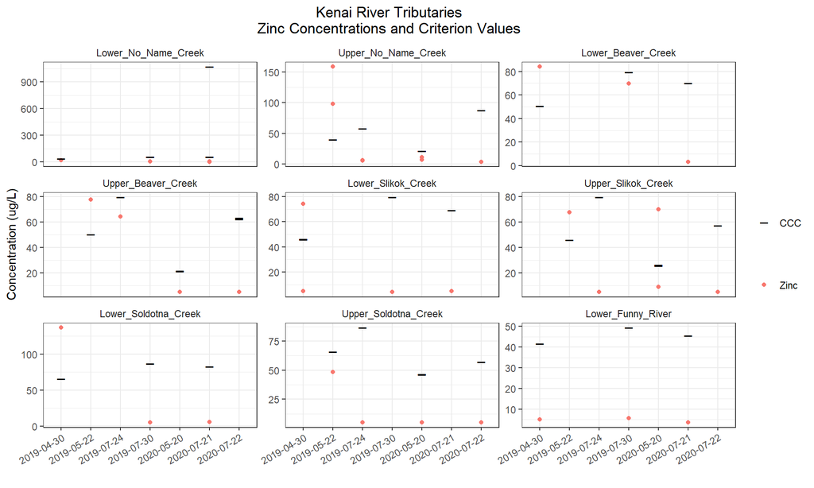

```r
# zn in tributaries
(zn_tribs <- tbl2_trib%>%
    filter(metal == "zn") %>%
  ggplot() +
  geom_point(aes(as.factor(date),as.numeric(met_val), color = "Zinc")) +
  geom_point(aes(as.factor(date),as.numeric(ccc_val), fill = "CCC"), shape = 95, size = 4) +
    scale_color_discrete(name = "") +
    scale_fill_discrete(name = "") +
  facet_wrap(site ~ ., scales = "free_y") +
  theme_bw() +
  cuzn_theme +
  xlab("") +
  ylab("Concentration (ug/L)") +
  ggtitle("Kenai River Tributaries\nZinc Concentrations and Criterion Values"))
```

```r
# save to output folder
ggsave("output/figures/zn_tribs.png")
```

#### Mainstem site plots

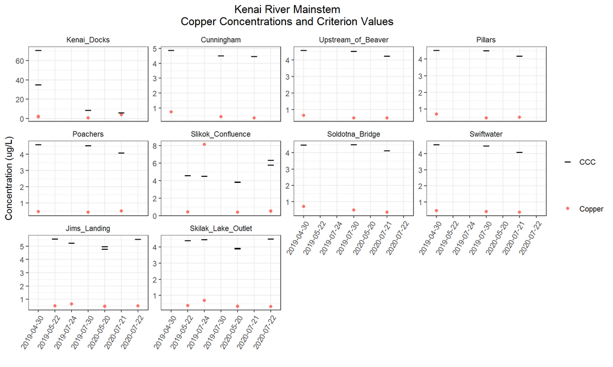

```r
## mainstem
ms_order <- c("City_of_Kenai_Docks",
              "Cunningham_Park",
              "Upstream_of_Beaver_Creek",
              "Pillars",
              "Poachers_Cove",
              "Slikok_Creek_Kenai_River_Confluence",
              "Soldotna_Bridge",
              "Swiftwater_Park",
              "Jims_Landing",
              "Skilak_Lake_Outlet")

# shorten site names
ms_sites <- c("City_of_Kenai_Docks" = "Kenai_Docks",
              "Cunningham_Park" = "Cunningham",
             "Upstream_of_Beaver_Creek" = "Upstream_of_Beaver",
              "Pillars" = "Pillars",
              "Poachers_Cove" = "Poachers",
              "Slikok_Creek_Kenai_River_Confluence" = "Slikok_Confluence",
              "Soldotna_Bridge" = "Soldotna_Bridge",
              "Swiftwater_Park" = "Swiftwater",
              "Jims_Landing" = "Jims_Landing",
              "Skilak_Lake_Outlet" = "Skilak_Lake_Outlet")

tbl2_ms <- tbl2 %>% filter(Habitat == "Mainstem")
tbl2_ms$site <- factor(tbl2_ms$site, levels = ms_order)

# common theme
cuzn_theme <- theme(
  strip.text.y = element_text(face = "bold", angle = 0),
  # modified x axis text angle
        axis.text.x = element_text(angle = 60, hjust = 1, vjust = 1),

        plot.title = element_text(hjust = 0.5),
        strip.background = element_blank())


# copper in mainstem
(cu_ms <- tbl2_ms %>%
    filter(metal == "cu") %>%
  ggplot() +
  geom_point(aes(as.factor(date),as.numeric(met_val), color = "Copper")) +
  geom_point(aes(as.factor(date),as.numeric(ccc_val), fill = "CCC"), shape = 95, size = 4) +
    scale_color_discrete(name = "") +
    scale_fill_discrete(name = "") +
  facet_wrap(site ~ ., scales = "free_y", labeller = as_labeller(ms_sites)) +
  theme_bw() +
  cuzn_theme +
  xlab("") +
  ylab("Concentration (ug/L)") +
  ggtitle("Kenai River Mainstem\nCopper Concentrations and Criterion Values"))
```

```r
# save to output folder
ggsave("output/figures/cu_ms.png")
```

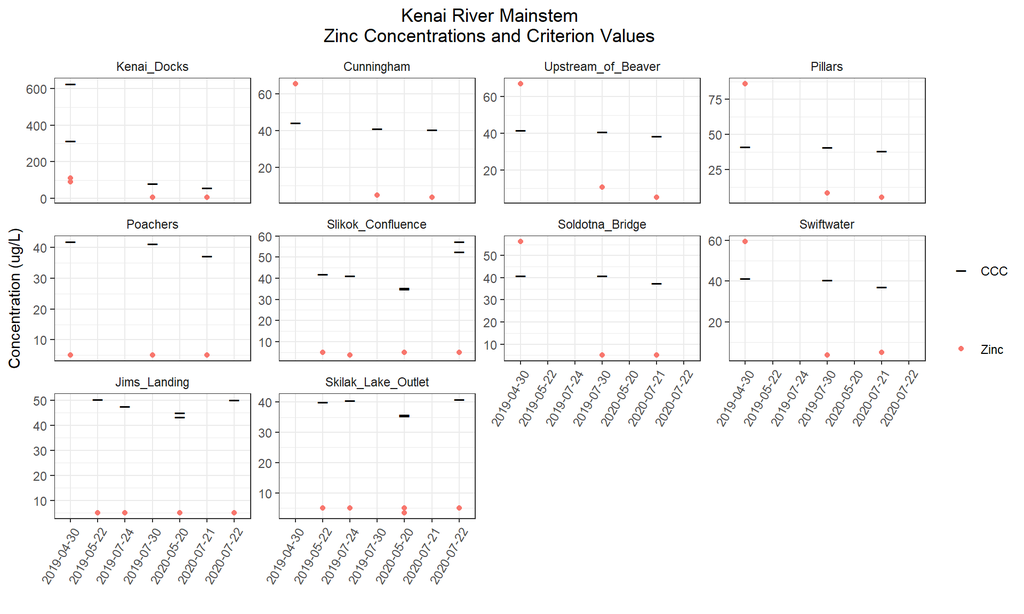

```r
# zn in mainstem
(zn_ms <- tbl2_ms %>%
    filter(metal == "zn") %>%
  ggplot() +
  geom_point(aes(as.factor(date),as.numeric(met_val), color = "Zinc")) +
  geom_point(aes(as.factor(date),as.numeric(ccc_val), fill = "CCC"), shape = 95, size = 4) +
    scale_color_discrete(name = "") +
    scale_fill_discrete(name = "") +
  facet_wrap(site ~ ., scales = "free_y", labeller = as_labeller(ms_sites)) +
  theme_bw() +
  cuzn_theme +
  xlab("") +
  ylab("Concentration (ug/L)") +
  ggtitle("Kenai River Mainstem\nZinc Concentrations and Criterion Values"))
```

```r
# save to output folder
ggsave("output/figures/zn_ms.png")
```

#### Overall

Is there an overall temporal trend in exceedances? (Year, season…?)

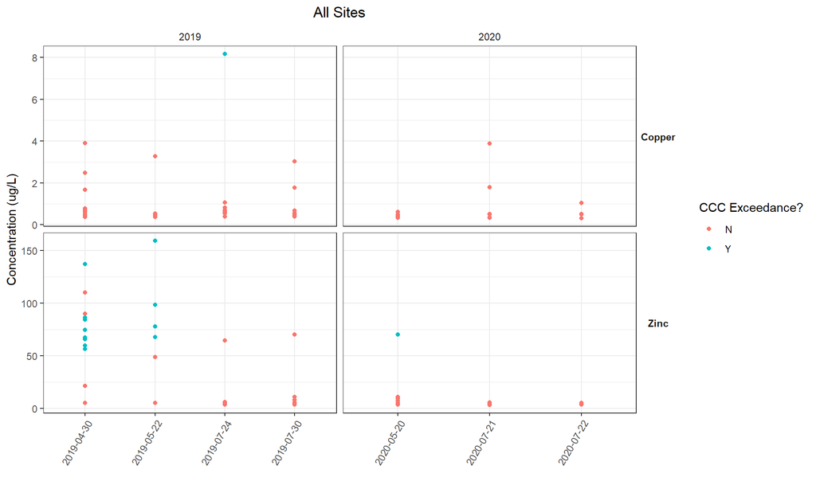

```r
# facet labels
facet_labs <- c(
  "cu" = "Copper",
  "zn" = "Zinc")

# plot
tbl2 %>%
  mutate(excd = ifelse(met_val > ccc_val,"Y","N"),
         year = year(date)) %>%
  ggplot(aes(as.factor(date),met_val, color = excd)) +
  geom_point() +
  facet_grid(metal ~ year, scales = "free", labeller = labeller(metal = facet_labs)) +
  xlab("") +
  ylab("Concentration (ug/L)") +
  theme_bw() +
  cuzn_theme +
  labs(color = "CCC Exceedance?") +
  ggtitle("All Sites")
```

```r
# save
ggsave("output/figures/overall_exceedances.png", width = 8, height = 6)
```

Are copper and zinc values correlated?

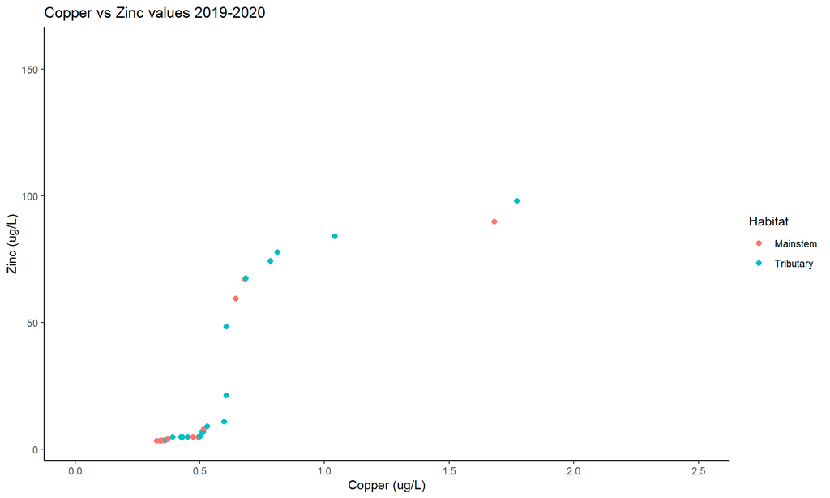

```r
tbl2 %>%
  ungroup() %>%
  group_by(metal) %>%
  mutate(r = row_number()) %>%
  select(metal,met_val,r,Habitat) %>%
  spread(key = metal, val = met_val) %>%
  ggplot(aes(cu,zn, color = Habitat)) +
  geom_point(size = 2) +
  theme_classic() +
  xlab("Copper (ug/L)") +
  ylab("Zinc (ug/L)") +
  xlim(0,2.5) +
  ggtitle("Copper vs Zinc values 2019-2020")
```

Relationship between copper and zinc appear to follow an approximately logistic relationship. Maybe we would we be able to determintaively observe the relationship with the full 20 year dataset?